# HW 02

Author

Kristy Feinberg

## Set Up

```r
library(tidyverse)
```

```r
olympics  <- read_csv('https://raw.githubusercontent.com/rfordatascience/tidytuesday/master/data/2021/2021-07-27/olympics.csv')
glimpse(olympics)
```

```
Rows: 271,116
Columns: 15
$ id     <dbl> 1, 2, 3, 4, 5, 5, 5, 5, 5, 5, 6, 6, 6, 6, 6, 6, 6, 6, 7, 7, 7, …
$ name   <chr> "A Dijiang", "A Lamusi", "Gunnar Nielsen Aaby", "Edgar Lindenau…
$ sex    <chr> "M", "M", "M", "M", "F", "F", "F", "F", "F", "F", "M", "M", "M"…
$ age    <dbl> 24, 23, 24, 34, 21, 21, 25, 25, 27, 27, 31, 31, 31, 31, 33, 33,…
$ height <dbl> 180, 170, NA, NA, 185, 185, 185, 185, 185, 185, 188, 188, 188, …
$ weight <dbl> 80, 60, NA, NA, 82, 82, 82, 82, 82, 82, 75, 75, 75, 75, 75, 75,…
$ team   <chr> "China", "China", "Denmark", "Denmark/Sweden", "Netherlands", "…
$ noc    <chr> "CHN", "CHN", "DEN", "DEN", "NED", "NED", "NED", "NED", "NED", …
$ games  <chr> "1992 Summer", "2012 Summer", "1920 Summer", "1900 Summer", "19…
$ year   <dbl> 1992, 2012, 1920, 1900, 1988, 1988, 1992, 1992, 1994, 1994, 199…
$ season <chr> "Summer", "Summer", "Summer", "Summer", "Winter", "Winter", "Wi…
$ city   <chr> "Barcelona", "London", "Antwerpen", "Paris", "Calgary", "Calgar…
$ sport  <chr> "Basketball", "Judo", "Football", "Tug-Of-War", "Speed Skating"…
$ event  <chr> "Basketball Men's Basketball", "Judo Men's Extra-Lightweight", …
$ medal  <chr> NA, NA, NA, "Gold", NA, NA, NA, NA, NA, NA, NA, NA, NA, NA, NA,…
```

```r
table(olympics$medal)
```

```
Bronze   Gold Silver
 13295  13372  13116
```

## Question 1

```r
gold_medalists <- olympics %>%
  filter(medal == "Gold")

glimpse(gold_medalists)
```

```
Rows: 13,372
Columns: 15
$ id     <dbl> 4, 17, 17, 17, 20, 20, 20, 20, 21, 40, 42, 56, 72, 73, 73, 76, …
$ name   <chr> "Edgar Lindenau Aabye", "Paavo Johannes Aaltonen", "Paavo Johan…
$ sex    <chr> "M", "M", "M", "M", "M", "M", "M", "M", "F", "M", "M", "M", "M"…
$ age    <dbl> 34, 28, 28, 28, 20, 30, 30, 34, 27, 31, 25, 21, 28, 23, 27, 22,…
$ height <dbl> NA, 175, 175, 175, 176, 176, 176, 176, 163, NA, NA, NA, 180, 18…
$ weight <dbl> NA, 64, 64, 64, 85, 85, 85, 85, NA, NA, NA, NA, 83, 86, 86, 82,…
$ team   <chr> "Denmark/Sweden", "Finland", "Finland", "Finland", "Norway", "N…
$ noc    <chr> "DEN", "FIN", "FIN", "FIN", "NOR", "NOR", "NOR", "NOR", "NOR", …
$ games  <chr> "1900 Summer", "1948 Summer", "1948 Summer", "1948 Summer", "19…
$ year   <dbl> 1900, 1948, 1948, 1948, 1992, 2002, 2002, 2006, 2008, 1960, 191…
$ season <chr> "Summer", "Summer", "Summer", "Summer", "Winter", "Winter", "Wi…
$ city   <chr> "Paris", "London", "London", "London", "Albertville", "Salt Lak…
$ sport  <chr> "Tug-Of-War", "Gymnastics", "Gymnastics", "Gymnastics", "Alpine…
$ event  <chr> "Tug-Of-War Men's Tug-Of-War", "Gymnastics Men's Team All-Aroun…
$ medal  <chr> "Gold", "Gold", "Gold", "Gold", "Gold", "Gold", "Gold", "Gold",…
```

**How many rows does the resulting dataset have?**

The new dataset has 13,372 rows.

## Question 2

**What’s the most appropriate plot to display these data?**

Scatter plot because we are plotting two quantitative variables against each other.

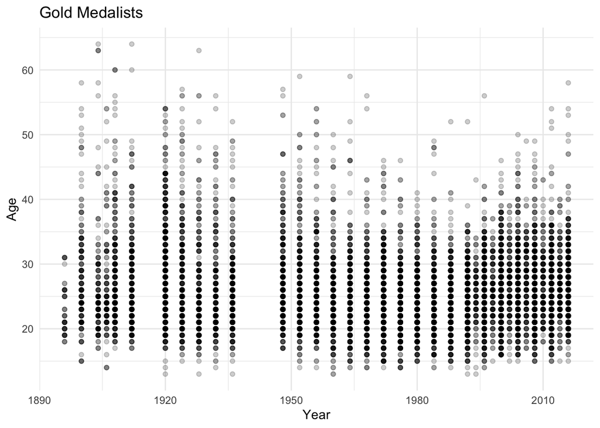

```r
ggplot(data = gold_medalists,
         aes(x = year, y = age)) +
  geom_point(alpha = .2)+
  labs(x = "Year",
       y = "Age",
       title = "Gold Medalists") +
  theme_minimal()
```

**How has the age of participants change across the years?**

As the years go on, the standard distribution of age has decreased. Meaning the spread of points far away from the mean has been decreasing.

**We are missing a lot of information because there are a lot of athletes that have the same age. This means we are overplotting. Can you think of a solution to this?**

“geom_point()” plots circles on top of each other and it is difficult to tell how many data points fall in one category. Instead by using “geom_jitter()”, there will be an added little bit of random noise to the location of the points.

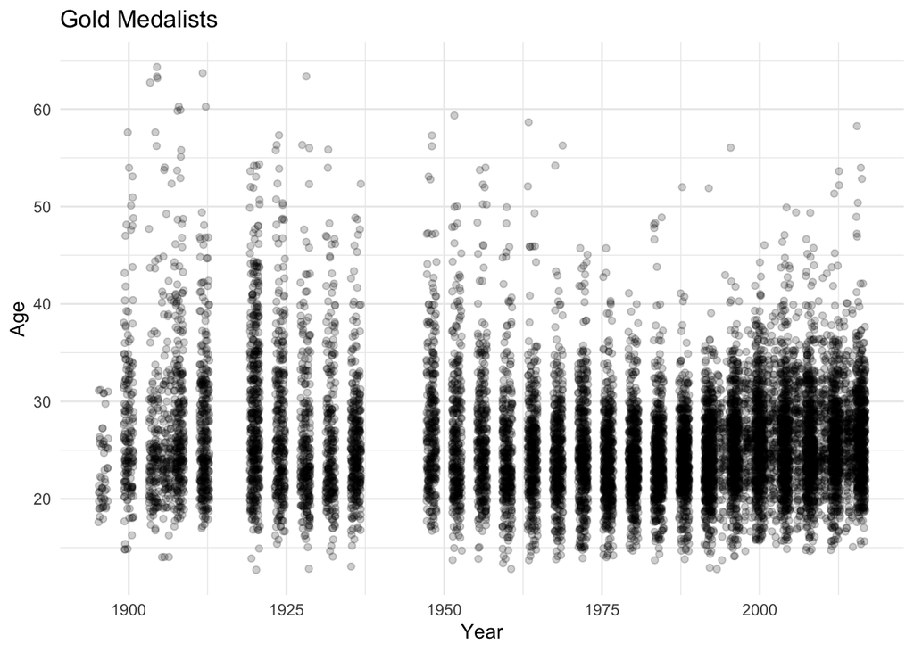

```r
ggplot(data = gold_medalists,
         aes(x = year, y = age)) +
  geom_jitter(alpha = 0.2)+
  labs(x = "Year",
       y = "Age",
       title = "Gold Medalists") +
  theme_minimal()
```

## Question 3

Plot year and gold medals won that year as a line graph.

```r
us_medals <- gold_medalists %>%
  filter(noc == "USA") %>%
  group_by(year) %>%
  summarise(num_medals = n())
```

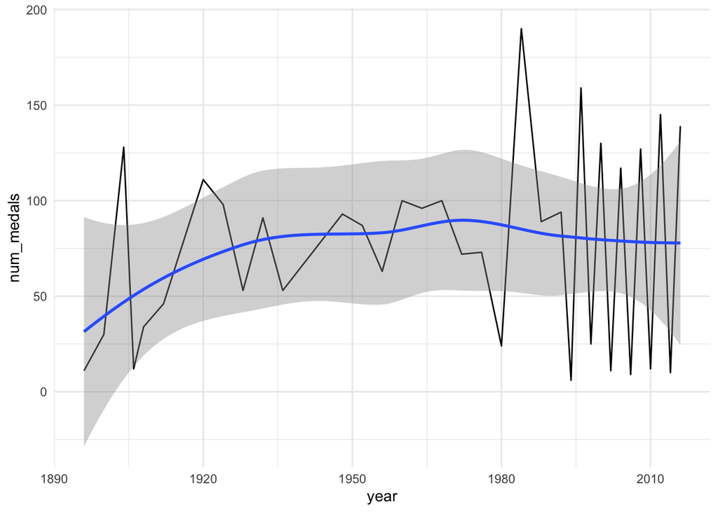

```r
ggplot(data = us_medals,
       aes(x = year,
           y = num_medals)) +
  geom_line() +
  geom_smooth() +
  theme_minimal()
```

> **What was the country’s most successful year? As a bonus, can you guess why the line is so wiggly (technical term) towards the end?**

> In the past the Olympics occurred every 4 years. But in 1994, they changed the games to occur every 2 years, one summer and one winter. This “wiggly” line is due to the increase in occurrences of the Olympics.

## Question 4

```r
two_events <- gold_medalists %>%
  filter(
    event == "Gymnastics Men's Individual All-Around"  |
      event == "Gymnastics Women's Individual All-Around" |
      event == "Athletics Women's 100 metres"   |
      event == "Athletics Men's 100 metres"
  )

glimpse(two_events)
```

```
Rows: 94
Columns: 15
$ id     <dbl> 519, 3281, 4198, 5396, 5547, 6890, 11495, 12166, 13029, 13029, …
$ name   <chr> "Harold Maurice Abrahams", "Simona Amnar (-Tabr)", "Nikolay Yef…
$ sex    <chr> "M", "F", "M", "M", "F", "M", "F", "F", "M", "M", "M", "M", "M"…
$ age    <dbl> 24, 20, 23, 23, 27, 28, 19, 30, 21, 25, 29, 22, 25, 29, 21, 22,…
$ height <dbl> 183, 158, 166, 167, 165, 183, 143, 175, 196, 196, 196, 183, 167…
$ weight <dbl> 75, 44, 60, 63, 52, 82, 47, 63, 95, 95, 95, 80, NA, NA, 66, 58,…
$ team   <chr> "Great Britain", "Romania", "Soviet Union", "Soviet Union", "Un…
$ noc    <chr> "GBR", "ROU", "URS", "URS", "USA", "CAN", "USA", "NED", "JAM", …
$ games  <chr> "1924 Summer", "2000 Summer", "1976 Summer", "1988 Summer", "19…
$ year   <dbl> 1924, 2000, 1976, 1988, 1984, 1996, 2016, 1948, 2008, 2012, 201…
$ season <chr> "Summer", "Summer", "Summer", "Summer", "Summer", "Summer", "Su…
$ city   <chr> "Paris", "Sydney", "Montreal", "Seoul", "Los Angeles", "Atlanta…
$ sport  <chr> "Athletics", "Gymnastics", "Gymnastics", "Gymnastics", "Athleti…
$ event  <chr> "Athletics Men's 100 metres", "Gymnastics Women's Individual Al…
$ medal  <chr> "Gold", "Gold", "Gold", "Gold", "Gold", "Gold", "Gold", "Gold",…
```

Filter the data set to only contains the gymnastics events.

```r
gymnastic_events <- two_events %>%
  filter(sport == "Gymnastics")

glimpse(gymnastic_events)
```

```
Rows: 45
Columns: 15
$ id     <dbl> 3281, 4198, 5396, 11495, 14549, 14549, 18826, 18826, 21402, 214…
$ name   <chr> "Simona Amnar (-Tabr)", "Nikolay Yefimovich Andrianov", "Vladim…
$ sex    <chr> "F", "M", "M", "F", "M", "M", "F", "F", "M", "M", "F", "F", "M"…
$ age    <dbl> 20, 23, 23, 19, 25, 29, 22, 26, 30, 35, 14, 18, 22, 16, 27, 27,…
$ height <dbl> 158, 166, 167, 143, 167, 167, 160, 160, NA, NA, 162, 148, 178, …
$ weight <dbl> 44, 60, 63, 47, NA, NA, 58, 58, NA, NA, 45, 45, 70, 50, 58, 58,…
$ team   <chr> "Romania", "Soviet Union", "Soviet Union", "United States", "It…
$ noc    <chr> "ROU", "URS", "URS", "USA", "ITA", "ITA", "TCH", "TCH", "URS", …
$ games  <chr> "2000 Summer", "1976 Summer", "1988 Summer", "2016 Summer", "19…
$ year   <dbl> 2000, 1976, 1988, 2016, 1908, 1912, 1964, 1968, 1952, 1956, 197…
$ season <chr> "Summer", "Summer", "Summer", "Summer", "Summer", "Summer", "Su…
$ city   <chr> "Sydney", "Montreal", "Seoul", "Rio de Janeiro", "London", "Sto…
$ sport  <chr> "Gymnastics", "Gymnastics", "Gymnastics", "Gymnastics", "Gymnas…
$ event  <chr> "Gymnastics Women's Individual All-Around", "Gymnastics Men's I…
$ medal  <chr> "Gold", "Gold", "Gold", "Gold", "Gold", "Gold", "Gold", "Gold",…
```

Make a histogram where age is in the x-axis.

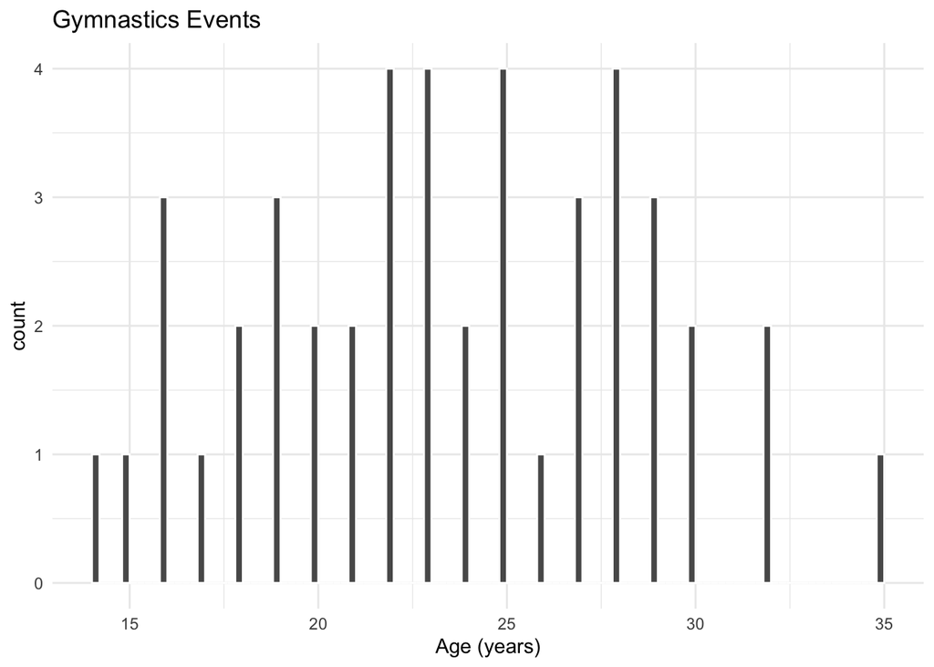

```r
ggplot(data = gymnastic_events,
       aes(x = age)) +
  geom_histogram(boundary = 0,        # start the first bin at 0
                 binwidth = .2,       # make the bins .2 (xG) units wide
                 color = "white") +   # make the bin borders white
  labs(x = "Age (years)",
       title = "Gymnastics Events") +
  theme_minimal()
```

**Briefly describe this distribution.**

The distribution appears to have two different bell curves or averages. This is due to the fact that women’s peak gymnastic age is much younger than for males and males tend to be in their prime athletic years for a longer period of time.

**Now, try to see whether there are differences between female and male athletes by using the `facet_wrap()` function.**

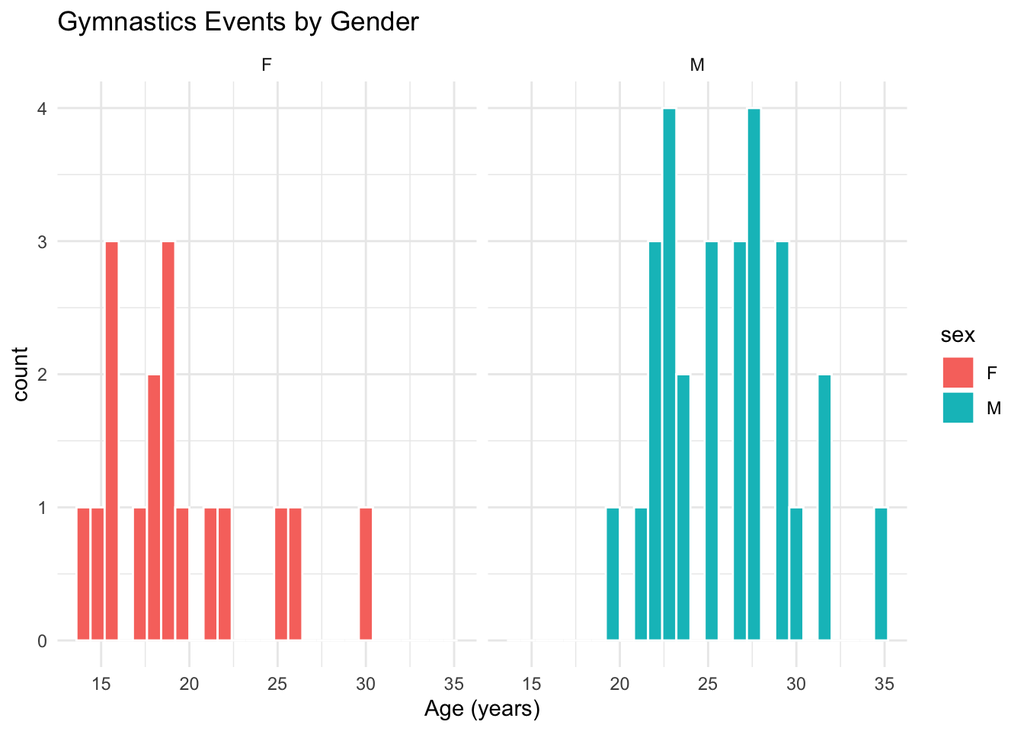

```r
ggplot(data = gymnastic_events,
       aes(x = age,
           group = sex,
           fill = sex)) +
  geom_histogram(boundary = 0,        # start the first bin at 0
                 binwidth = .8,       # make the bins .2 (xG) units wide
                 color = "white",     # make the bin borders white
                 position = "dodge") +
  facet_wrap(~ sex) +
  labs(x = "Age (years)",
       title = "Gymnastics Events by Gender") +
  theme_minimal()
```

**What athletes tend to be older?**

Males, on average, tend to be older than females.

## Question 5

Make a boxplot where the x-axis is event and the y-axis is height.

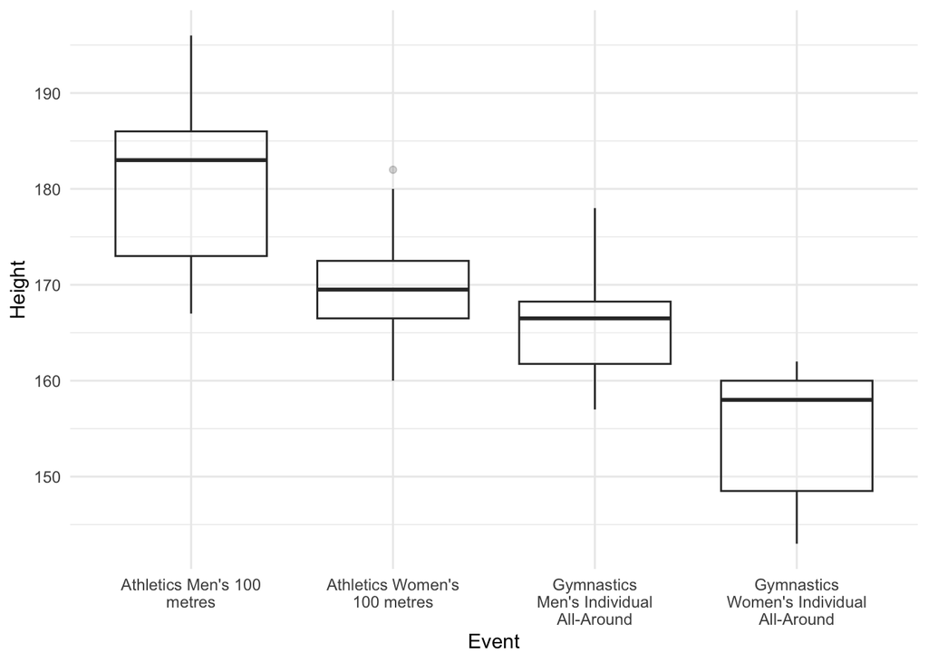

```r
ggplot(data = two_events,
       mapping = aes(x = event,
                     y = height)) +
  labs(x = "Event",
       y = "Height") +
  geom_boxplot(alpha = 0.2) +
  theme_minimal() +
  scale_x_discrete(labels = function(x)    #wraps the event labels
    stringr::str_wrap(x, width = 20))
```

**Briefly describe your results.**

For both the 100 Meter and Gymnastics All-Around, on average, men are taller than females. Also, the average heights for both men and women are greater for those participating in the 100 metres than for gymnasts.

## Question 6

```r
us_medalists <- gold_medalists %>%
  filter(noc == "USA")
```

Make a barplot where the x axis is `year`. Make sure you can see parallel lines for female and male athletes.

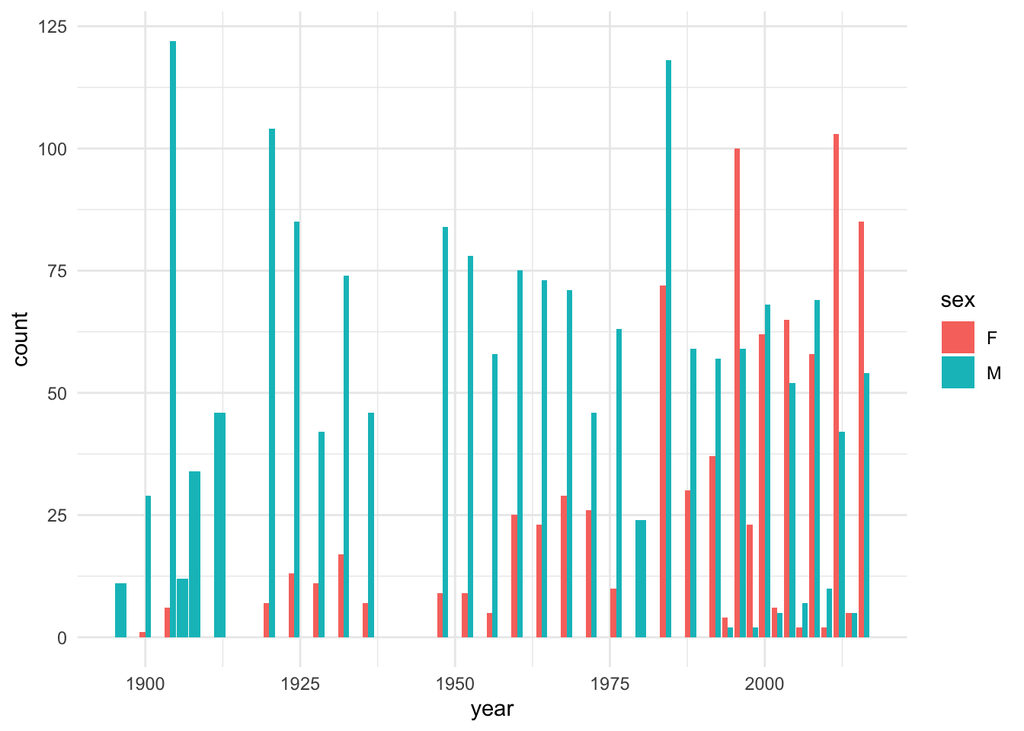

```r
ggplot(data = us_medalists,
       mapping = aes(x = year,
                     fill = sex)) +
  geom_bar(position="dodge") +
  theme_minimal()
```

**Can you notice any patterns?**

In the early 1900’s there were very few female gold medalists. It wasn’t until the 1980’s that females started to hold more gold medals. This could be due to the fact that women were competing in fewer events than men.